# Logisitic Regression with Categorical Predictors

## Individual trees for classification

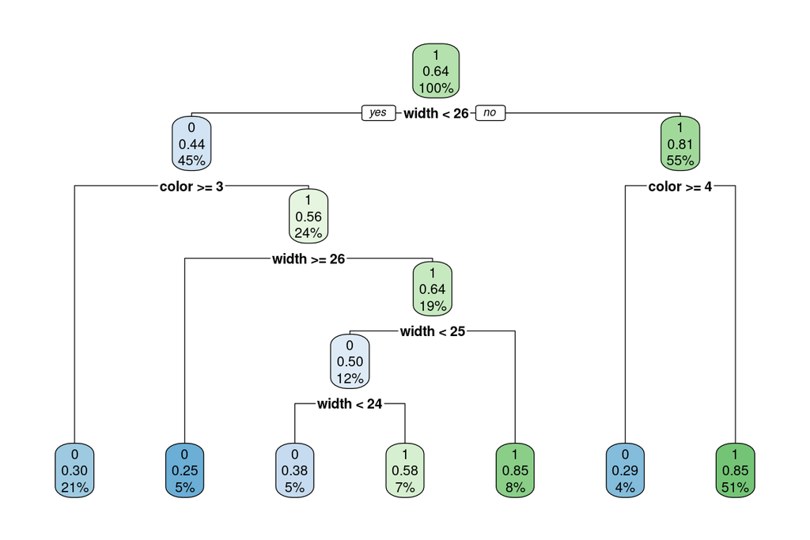

```r
crab <- read.table("http://www.stat.ufl.edu/~aa/cat/data/Crabs.dat",
                   header = TRUE)

crab$y <- as.factor(crab$y)

ff <- rpart(y ~ width + color, data = crab)
rpart.plot(ff)
```

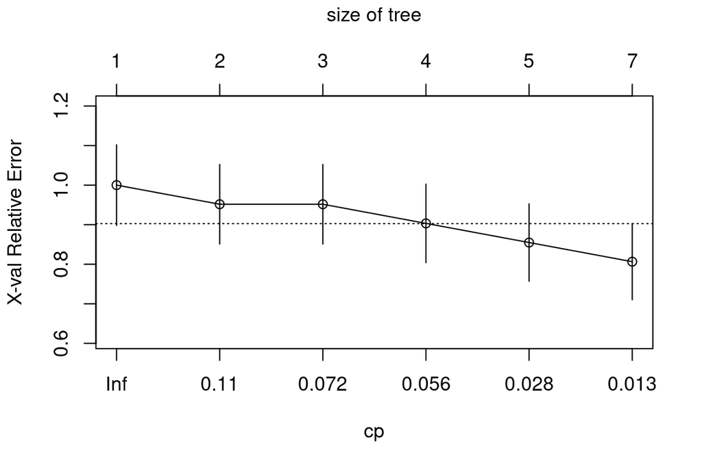

```r
plotcp(ff)
```

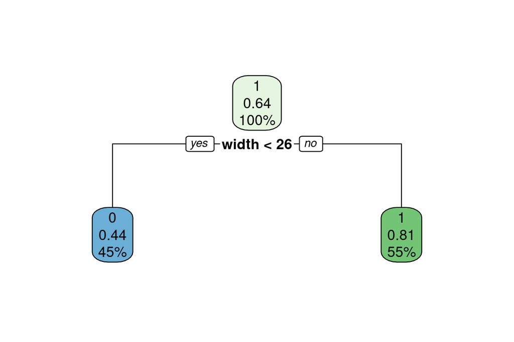

```r
rpart.plot(prune(ff, cp = 0.11))
```

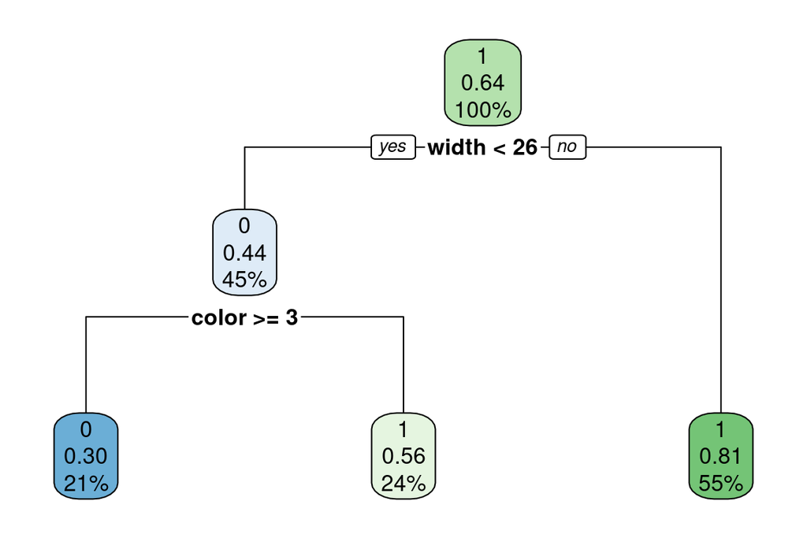

```r
rpart.plot(prune(ff, cp = 0.072))
```

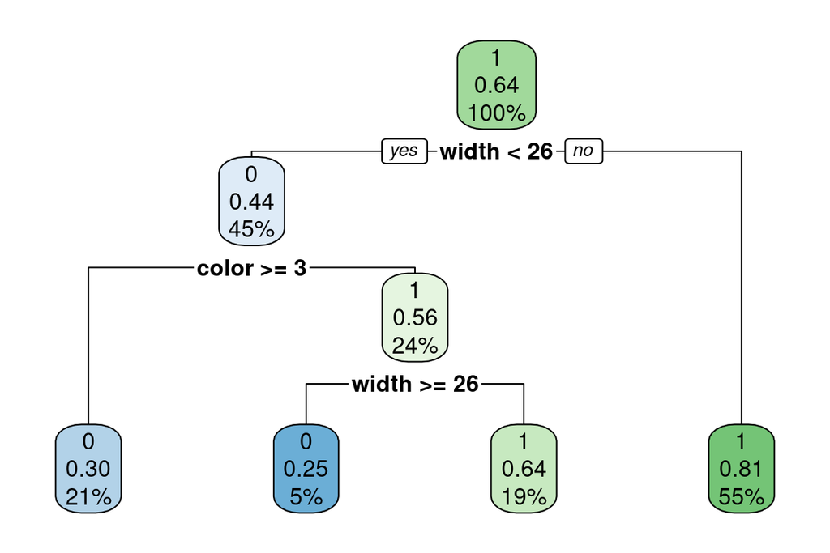

```r
rpart.plot(prune(ff, cp = 0.056))
```

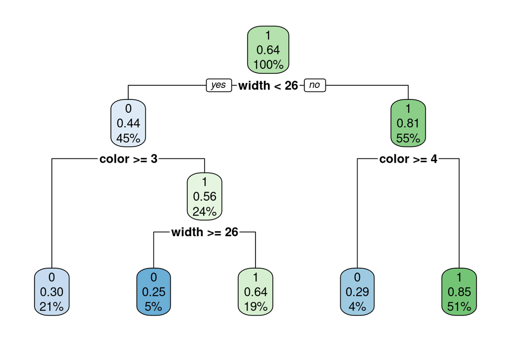

```r
rpart.plot(prune(ff, cp = 0.028))
```

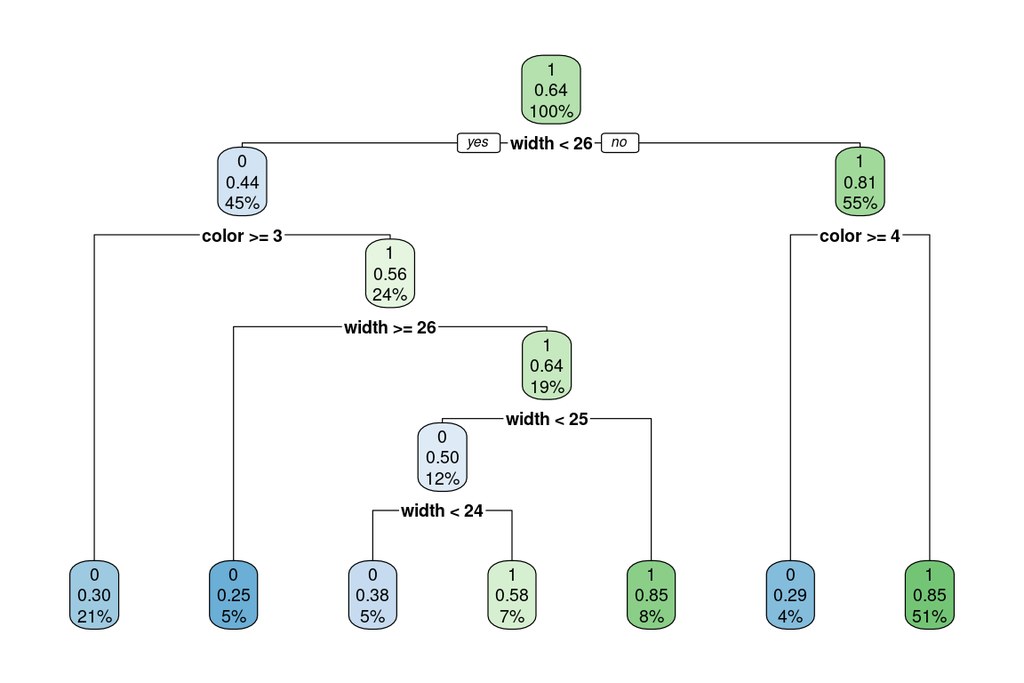

```r
rpart.plot(prune(ff, cp = 0.013))
```

### Tree building

We need a metric for assessing where the splits should be. For each of these, let $p_{mk}$ denote the propoprtion of observations in node $m$ that are members of class $k$

1. **Classification Error Rate:** This is defined as the proportion of observations in node $m$ that do not belong to the max class $k$

$$E = 1 - max_k (\hat{p}_{mk})$$
However, this is not sensitive to different forms of error that may be relevant. For example, consider two nodes:

$$\mathcal{N}_1 = \{A, A, A, A, A, B, B, B, B\}, \\
\mathcal{N}_2 = \{A, A, A, A, A, B, C, C, D\}$$
these both have the same error, having 5/9 of the observations belonging to class A; yet Node 1 is superior in that it more cleanly partitions our classification space.

2. **Gini Purity Index:** The Gini Purity Index, or Gini index, is a measure of total variance across each of the classes in node M

$$G = \sum_{k=1}^K \hat{p}_{mk} (1 - \hat{p}_{mk})$$
This value will be minimized if all of the values for $\hat{p}_{mk}$ are close to 0 or 1. In practice, this is the metric most often used

### Sensitivy

One problem with having a single tree is that it can be highly sensitive to the particulars of the data. Here, we create two crab datasets that are simply bootstrapped samples of the first. Compare the resulting trees:

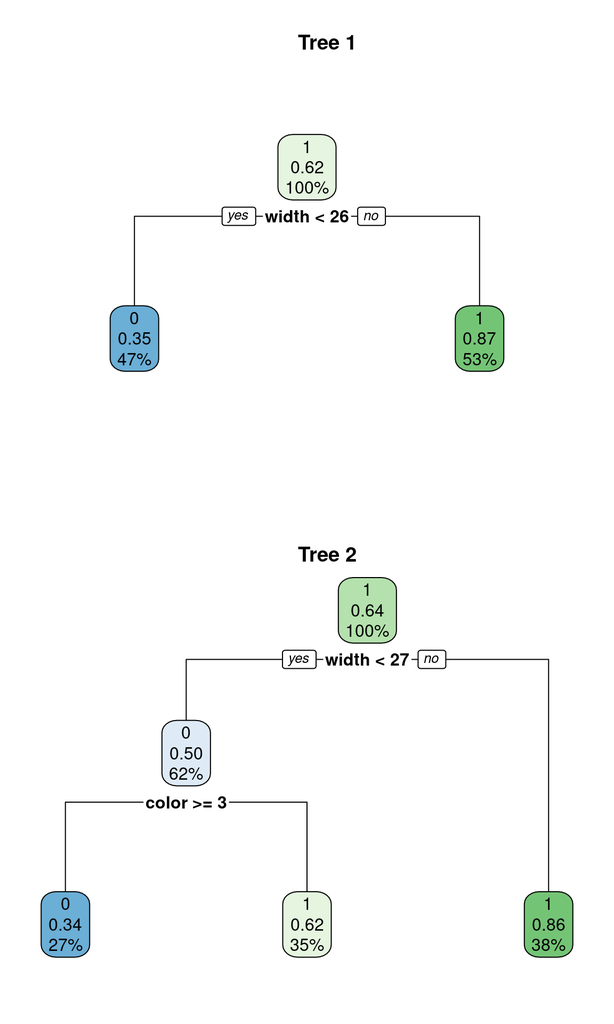

```r
set.seed(123)
crab1 <- crab[sample(1:nrow(crab), nrow(crab), replace = TRUE), ]
crab2 <- crab[sample(1:nrow(crab), nrow(crab), replace = TRUE), ]

ff1 <- rpart(y ~ width + color, data = crab1, method = "class")
ff2 <- rpart(y ~ width + color, data = crab2, method = "class")

par(mfrow = c(2, 1))
rpart.plot(prune(ff1, 0.11))
title("Tree 1")
rpart.plot(prune(ff2, 0.11))
title("Tree 2")
```

### Advantage and Disadvantage of Trees

**Advantage**

- Easy to explain
- Easy to display graphically
- Can handle categorical variables without dummy vars
- Makes decision making for clinicians easier

**Disadvantage**

- Not much predictive accuracy
- Sensitive to small changes

## Ensemble Methods

Ensemble methods are those that combine many simple methods into one more powerful. In this context, it will refer to creating many trees and using them collectively

### Bagging

The idea of bagging is pretty simple: create $B$ bootstraps of your (training) data, construct a tree, $\hat{f}^{*b}(x)$ for each, then average your predictions for each observation:

$$\hat{f}_{\text{bag}}(x) = \frac1B \sum_{b=1}^B \hat{f}^{*b}(x)$$
Classification, then, is determined by a majority vote across the trees.

The general idea is that averaging across a large number of bootstraps will leave the mean estimates the same while reducing variance; as such, we can use as large a value for $B$ as we wish without fear of over-fitting.

The process for constructing these trees also implies a method for testing them. On average, each bootstrap will sample 2/3 of the total dataset, leaving 1/3 in each iteration unsampled. These are referred to as *out-of-bag (OOB)* observations. With $B$ total bootstraps, each observation will be in the OOB category about $B/3$ times. Computing error rates on these OOB observations at each iteration then allows us to estimate predictive value without the need for cross validation or partitioning our data into test/train sets